# Baylor University Enrollment Analytics 2021 to 2024

Peer Benchmarking Report

Kelly Adu-Gyamfi

June 03, 2026

This report takes a close look at Baylor University’s enrollment trends, student outcomes, financial aid profile, and demographic makeup measured against six peer institutions using real federal IPEDS data from 2021 through 2024. The goal is straightforward: give Baylor’s leadership the kind of honest, side-by-side comparison that informs real decisions.

# Section 1 Enrollment Trends 2021 to 2024

Baylor’s headcount has been remarkably stable over the past four years, hovering between 20,600 and 20,800 students. That kind of flat-line stability is actually harder to maintain than it looks it means retention and new enrollments are keeping pace with each other. Graduate enrollment has been the quiet story, climbing from 5,435 in 2021 to 5,711 in 2024, suggesting Baylor is gradually building out its research and professional programs.

## Baylor Enrollment by Student Type

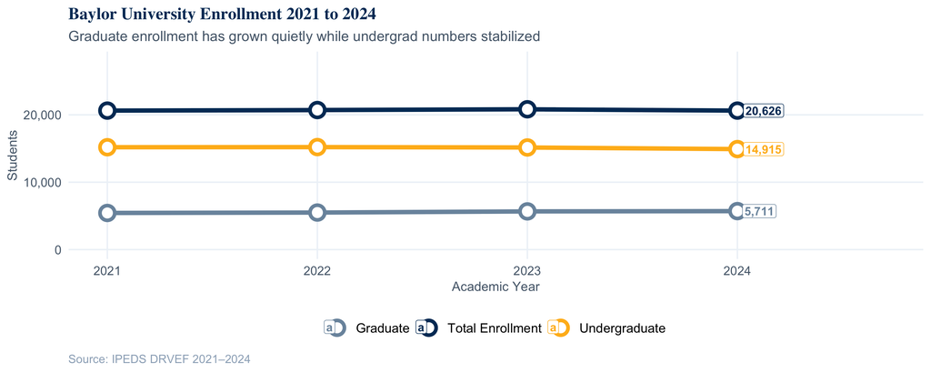

## How Baylor Sizes Up Against Peers

Texas A&M’s 78,321 students make it a different kind of institution a flagship public university with a very different mission. Baylor sits in a more meaningful comparison group with TCU (12,938) and SMU (12,116), where it’s actually the largest. The enrollment gap with UT Austin (53,864) is significant, but so is the difference in institutional type, selectivity, and cost structure.

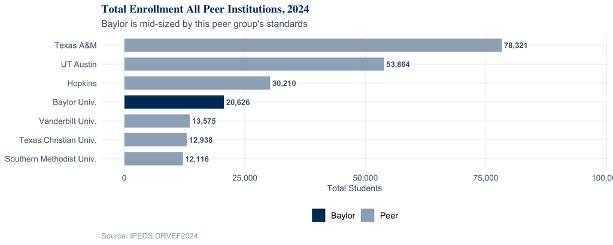

## Year-Over-Year Enrollment Change

Baylor Year-Over-Year Enrollment Change

| Year | Enrollment | Prior Year | Change | Change % |
| --- | --- | --- | --- | --- |
| 2,021 | 20,626 | NA | NA | NA |
| 2,022 | 20,709 | 20,626 | 83 | 0.4 |
| 2,023 | 20,824 | 20,709 | 115 | 0.6 |
| 2,024 | 20,626 | 20,824 | -198 | -1.0 |

## Undergraduate vs Graduate Mix

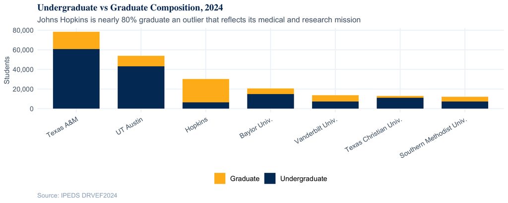

# Section 2 Student Outcomes

Graduation and retention rates are where institutions are held accountable and where the most important equity questions surface. Baylor’s 80% six-year graduation rate is respectable, though it trails Vanderbilt and Hopkins, both at 94%. The harder numbers are the equity gaps: an 11-point difference between White and Black graduation rates, and a 10-point gap for Hispanic students. Those gaps aren’t unique to Baylor they show up across this entire peer group but they’re worth naming directly.

## 6-Year Graduation Rate

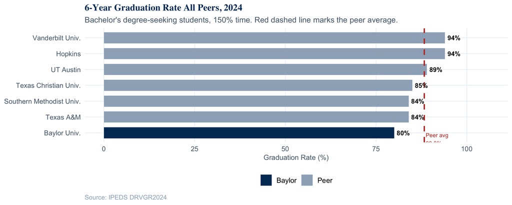

## Graduation Rates by Race and Pell Status

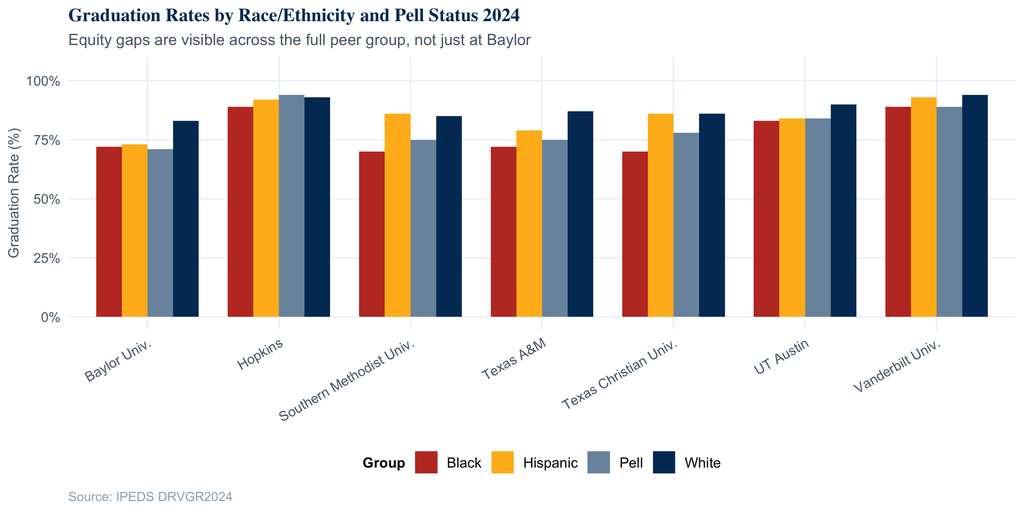

## Baylor Equity Gap Summary

Baylor University Graduation Rate Equity Gaps, 2024

| Overall | White | Black | Hispanic | Pell | White–Black Gap | White–Hispanic Gap | Non-Pell vs Pell |
| --- | --- | --- | --- | --- | --- | --- | --- |
| 80 | 83 | 72 | 73 | 71 | 11 | 10 | 13 |

## First-Year Retention Rate

[figure not shown]

# Section 3 Financial Aid and Affordability

Baylor’s financial aid story has two sides. On one hand, 99% of its students receive some form of aid that’s near-universal coverage and the highest figure in this peer group by a wide margin. On the other hand, the average institutional grant of $25,690 is considerably lower than what Vanderbilt ($61,870) and Johns Hopkins ($57,131) offer. Baylor’s approach is broad rather than deep: get aid to almost everyone, rather than giving very large amounts to fewer students.

## Aid Coverage by Type

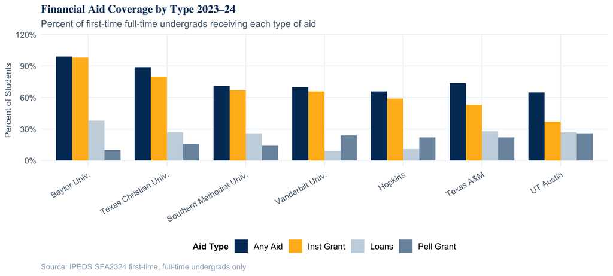

## Average Institutional Grant

The grant size comparison requires some context. Vanderbilt and Hopkins offer dramatically larger grants but they also cover a much smaller share of students (66% and 59% respectively). Baylor’s 98% institutional grant coverage at $25,690 reflects a deliberate choice to prioritize access over depth. Texas A&M and UT Austin offer very small institutional grants because they’re public institutions with lower tuition to begin with.

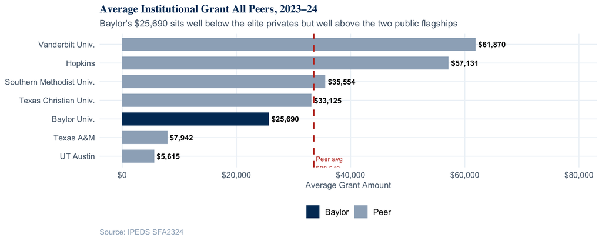

## Full Financial Aid Summary

Financial Aid Summary All Peers, 2023–24

| Institution | % Any Aid | % Pell | Avg Pell | % Inst Grant | Avg Grant | % Loans | Avg Loan |
| --- | --- | --- | --- | --- | --- | --- | --- |
| Baylor University | 99% | 10% | $6,332 | 98% | $25,690 | 38% | $15,571 |
| Texas Christian University | 89% | 16% | $6,540 | 80% | $33,125 | 27% | $14,942 |
| Southern Methodist University | 71% | 14% | $6,741 | 67% | $35,554 | 26% | $13,116 |
| Vanderbilt University | 70% | 24% | $7,451 | 66% | $61,870 | 9% | $12,263 |
| Johns Hopkins University | 66% | 22% | $7,784 | 59% | $57,131 | 11% | $11,969 |
| Texas A&M University | 74% | 22% | $6,245 | 53% | $7,942 | 28% | $8,684 |
| Univ of Texas at Austin | 65% | 26% | $6,024 | 37% | $5,615 | 27% | $6,066 |

# Section 4 Demographics and Geographic Draw

Baylor draws 63% of its first-time freshmen from within Texas a figure that places it squarely between the Texas public flagships (which are even more regional) and the national private universities like Vanderbilt and Hopkins, which pull most of their students from out of state. Demographically, the most notable trend is Hispanic enrollment climbing from 15% in 2021 to 17% in 2024, which tracks with Texas’s broader demographic shifts and reflects real progress in Baylor’s recruitment reach.

## Enrollment by Race and Ethnicity

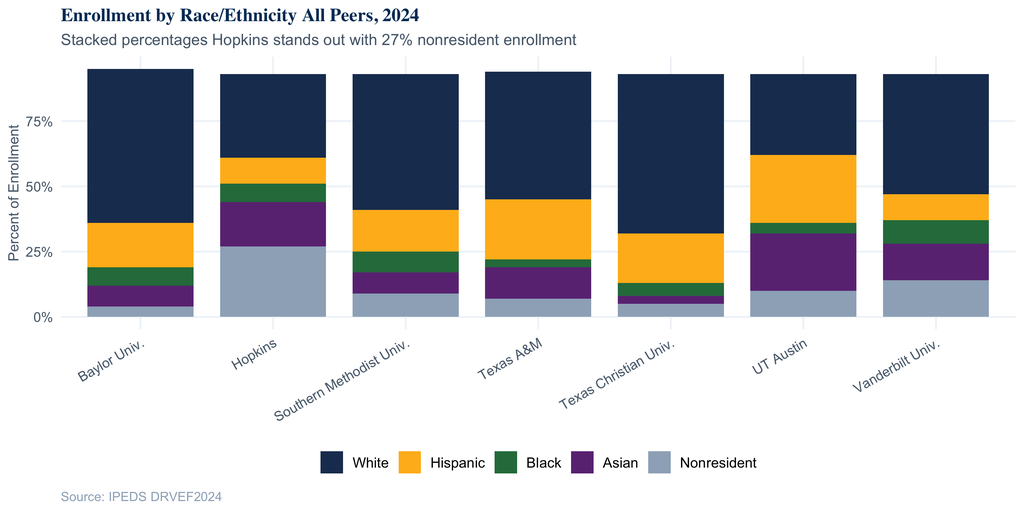

## Freshmen Geographic Origin

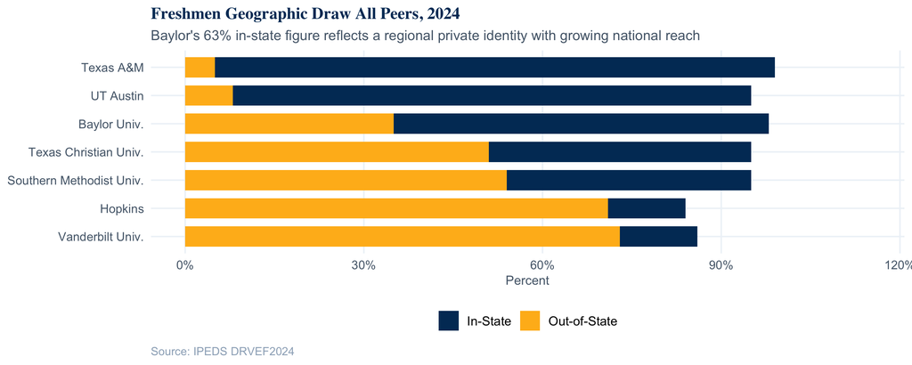

## Baylor Hispanic Enrollment Trend 2021 to 2024

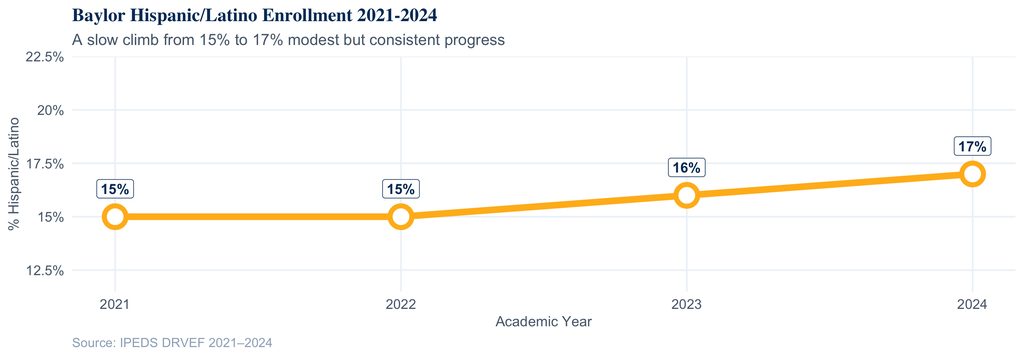

# Section 5 Peer Benchmarking Summary

Pulling everything together, Baylor’s institutional profile is distinctive in ways that matter strategically. It has near-universal financial aid coverage that no other peer can match. Its student body is predominantly undergraduate and draws heavily from Texas. Outcomes are solid but trail the elite research universities which is an honest description of where Baylor sits in the national landscape. The correlation analysis below surfaces which metrics tend to move together across this peer group.

## Master KPI Comparison

Comprehensive Peer Benchmarking All Key Metrics, 2024

| Institution | Enrollment | Grad Rate | Retention | % Any Aid | Avg Grant | % Hispanic | % Women | % In-State |
| --- | --- | --- | --- | --- | --- | --- | --- | --- |
| Baylor University | 20,626 | 80% | 91% | 99% | $25,690 | 17% | 61% | 63% |
| Texas A&M University | 78,321 | 84% | 94% | 74% | $7,942 | 23% | 47% | 94% |
| Univ of Texas at Austin | 53,864 | 89% | 97% | 65% | $5,615 | 26% | 56% | 87% |
| Johns Hopkins University | 30,210 | 94% | 98% | 66% | $57,131 | 10% | 53% | 13% |
| Vanderbilt University | 13,575 | 94% | 96% | 70% | $61,870 | 10% | 56% | 13% |
| Texas Christian University | 12,938 | 85% | 93% | 89% | $33,125 | 19% | 61% | 44% |
| Southern Methodist University | 12,116 | 84% | 91% | 71% | $35,554 | 16% | 50% | 41% |

## Baylor vs Peer Average

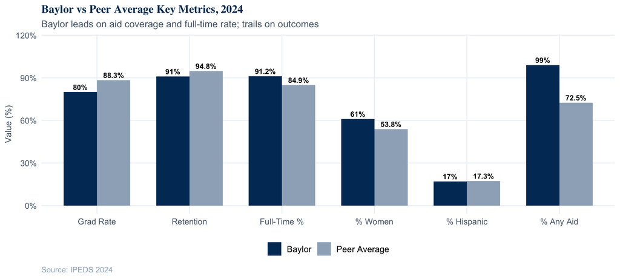

# Section 6 Statistical Analysis

With only seven institutions in this peer set, statistical models should be read cautiously no regression can be generalized from seven data points. What the analysis below does offer is a sense of which metrics correlate with each other across this specific group, and where Baylor’s profile sits relative to the average.

## Correlation Matrix

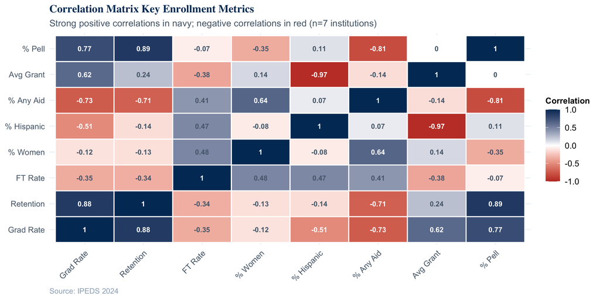

## Descriptive Statistics

Descriptive Statistics 7-Institution Peer Group, 2024

| Metric | Mean | SD | Min | Max | Baylor |
| --- | --- | --- | --- | --- | --- |
| Total Enrollment | 31664.3 | 25343.2 | 12116.0 | 78321.0 | 20626.0 |
| Grad Rate | 87.1 | 5.4 | 80.0 | 94.0 | 80.0 |
| Retention | 94.3 | 2.8 | 91.0 | 98.0 | 91.0 |
| FT Rate | 85.8 | 13.7 | 57.9 | 97.4 | 91.2 |
| % Any Aid | 76.3 | 12.8 | 65.0 | 99.0 | 99.0 |
| Avg Inst Grant ($) | 32418.1 | 21799.2 | 5615.0 | 61870.0 | 25690.0 |

# Data Pipeline

**How this report was built:** Raw IPEDS CSV files were imported into SAS using PROC IMPORT, cleaned and standardized through a 10-program pipeline following Bronze-Silver-Gold medallion architecture, then exported as Gold-layer CSVs. Those files were read directly into this R Markdown document and visualized using ggplot2. The same Gold-layer CSVs also feed the Power BI dashboard which I am still working on.

Report generated: `June 03,2026` · Data source: IPEDS 2024 (National Center for Education Statistics) · Research Analyst: Kelly Adu-Gyamfi ·